# One-way ANOVA example - Crop yields

# Problem

(source: Crawley, The R book)

We have an experiment in which crop yields per unit area were measured from 10 randomly selected fields on each of three soil types. All fields were sown with the same variety of seed and provided with the same fertilizer and pest control inputs.

The question is whether soil type significantly affects crop yield, and if so, to what extent. ci sono differenze significative nei tre suoli per quanto riguarda i tre tipi di resa?

```r
rm(list = ls())
sand <- c(6,10,8,6,14,17,9,11,7,11)
clay <- c(17,15,3,11,14,12,12,8,10,13)
loam <- c(13,16,9,12,15,16,17,13,18,14)
dati <- data.frame(sand,clay,loam)
dati
```

| sand | clay | loam |
| --- | --- | --- |
| 6 | 17 | 13 |
| 10 | 15 | 16 |
| 8 | 3 | 9 |
| 6 | 11 | 12 |
| 14 | 14 | 15 |
| 17 | 12 | 16 |
| 9 | 12 | 17 |
| 11 | 8 | 13 |
| 7 | 10 | 18 |
| 11 | 13 | 14 |

# Tasks

- Calculate the mean for each soil and make a boxplot for the data
- The data format is not appropriate for subsequent analysis, prepare the data by creating a new data frame with a column for the soil type!
- One of the assumptions of ANOVA is about the homogeneity of variances - check for heteroschedasticity! (cerchiamo quindi che le varianze siano omogenee per i diversi livelli del fattore)
- Continue with the analysis of variance
- Graphically check for the assumptions
- Fit a linear model to the data to find out between which soil types the differences are actually significant

## Calculate the mean for each soil and make a boxplot for the data

```r
colMeans(dati)
```

```
sand clay loam
 9.9 11.5 14.3
```

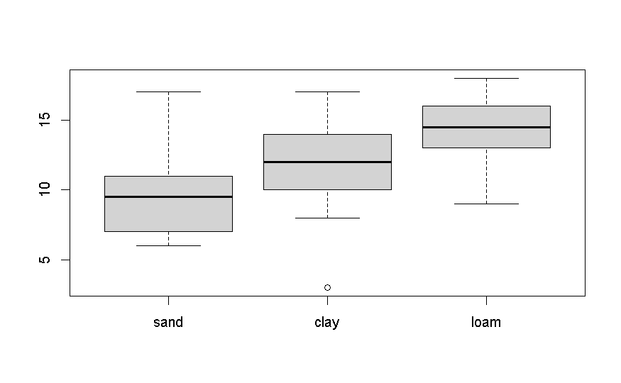

```r
boxplot(dati)
```

## Change the data format

```r
soil.type <- c(rep("sand",10),
               rep("clay",10),
               rep("loam",10))
yields <- c(sand, clay, loam)
dati.new <- data.frame(soil.type, yields)
dati.new
```

| soil.type | yields |
| --- | --- |
| sand | 6 |
| sand | 10 |
| sand | 8 |
| sand | 6 |
| sand | 14 |
| sand | 17 |
| sand | 9 |
| sand | 11 |
| sand | 7 |
| sand | 11 |

[output cut: 20 more lines]

ma questo non è un dataset ordinato come lo vorrebbe una macchina, noi vogliamo che ci sia una colonna unica per la variabile “tipo di suolo”. ## Check for heteroschedasticity

```r
by(dati.new$yields, dati.new$soil.type, var)
```

```
dati.new$soil.type: clay
[1] 15.38889
----------------------------------------------------------------------
dati.new$soil.type: loam
[1] 7.122222
----------------------------------------------------------------------
dati.new$soil.type: sand
[1] 12.54444
```

```r
fligner.test(yields ~ soil.type, data=dati.new)
```

```
    Fligner-Killeen test of homogeneity of variances

data:  yields by soil.type
Fligner-Killeen:med chi-squared = 0.36507, df = 2, p-value = 0.8332
```

possiamo fare un test specifico per testare l’eteroschedasticità (ultima riga sopra). There is no evidence of any significant difference in variance across the three samples, so it is legitimate to continue with the analysis.

## Continue with the analysis of variance

yields=rese, raccolto.

```r
anova.yields <- aov(yields ~ soil.type, data=dati.new)
summary(anova.yields)
```

```
            Df Sum Sq Mean Sq F value Pr(>F)
soil.type    2   99.2   49.60   4.245  0.025 *
Residuals   27  315.5   11.69
---
Signif. codes:  0 ‘***’ 0.001 ‘**’ 0.01 ‘*’ 0.05 ‘.’ 0.1 ‘ ’ 1
```

“le rese dei tre tipi di suoli sono diverse, o quantomeno c’è uno dei tre suoli che differisce significativamente dagli altri. sotto vediamo un altro modo con cui possiamo scrivere l’analisi della varianza.

```r
anova(lm(yields ~ soil.type, data=dati.new))
```

```
Analysis of Variance Table

Response: yields
          Df Sum Sq Mean Sq F value  Pr(>F)
soil.type  2   99.2  49.600  4.2447 0.02495 *
Residuals 27  315.5  11.685
---
Signif. codes:  0 ‘***’ 0.001 ‘**’ 0.01 ‘*’ 0.05 ‘.’ 0.1 ‘ ’ 1
```

vediamo che è la stessa analisi poichè mi viene restituito lo stesso valore di P. ## Graphically check for the assumptions vediamo un check completo di tutti gli assunti dell’analisi della varianza.

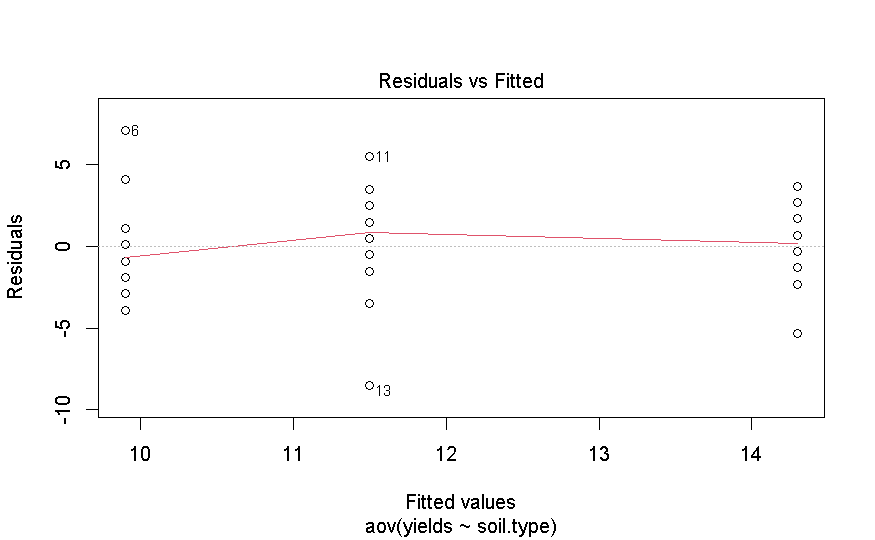

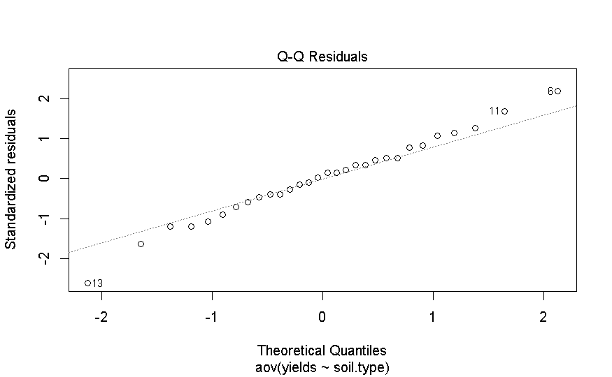

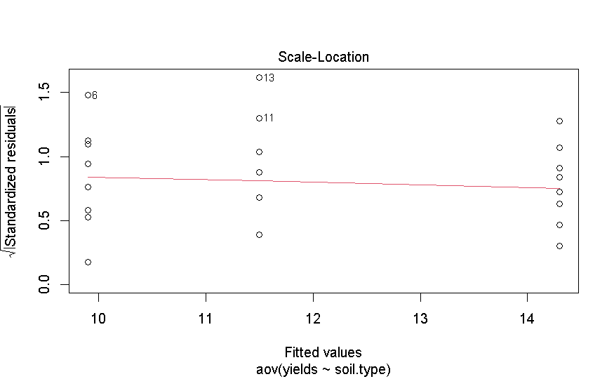

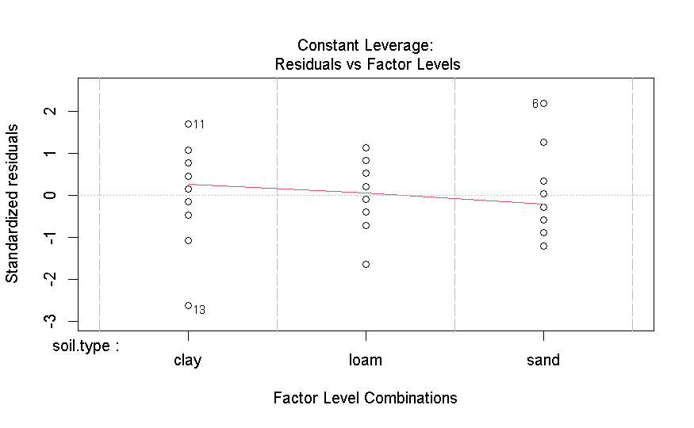

```r
anova.yields <- aov(yields ~ soil.type, data=dati.new)
plot(anova.yields)
```

sembra tutto abbastanza pulito, tranquillo. The first plot check the most important assumption of constancy of variance: there should be no pattern in the residuals against the fitted values, and, indeed, there is none.  
The second plot tests the assumption of normality of errors: there should be a straight-line relationship between our standardized residuals and theoretical quantiles derived from a normal distribution. Points 6, 11 and 13 lie a little off the straight line, but this is nothing to worry about.  
The third plot shows that the residuals are well behaved.  
The fourth plot shows that there are no highly influential values that might be distorting the parameter estimates.

## Fit a linear model to the data to find out between which soil types the differences are actually significant

andiamo a testare

```r
mod <- lm(yields ~ soil.type, data=dati.new)
summary(mod)
```

```
Call:
lm(formula = yields ~ soil.type, data = dati.new)

Residuals:
   Min     1Q Median     3Q    Max
  -8.5   -1.8    0.3    1.7    7.1

Coefficients:
              Estimate Std. Error t value Pr(>|t|)
(Intercept)     11.500      1.081  10.638  3.7e-11 ***
soil.typeloam    2.800      1.529   1.832   0.0781 .
soil.typesand   -1.600      1.529  -1.047   0.3046
---
Signif. codes:  0 ‘***’ 0.001 ‘**’ 0.01 ‘*’ 0.05 ‘.’ 0.1 ‘ ’ 1

Residual standard error: 3.418 on 27 degrees of freedom
Multiple R-squared:  0.2392,    Adjusted R-squared:  0.1829
F-statistic: 4.245 on 2 and 27 DF,  p-value: 0.02495
```

l’’output del modello lm mi dà un pò più di dettaglio, dicendomi che il soil type loam è quasi significativamente diverso rispetto a clay, che è stata inglobata nell’intercetta del modello ( )il primo livello in ordine alfabetico viene inglobato da R. quindi adesso voglio fare un relevel per ordinare i dati in maniera strategica per confrontare la resa di sand con loam anche.

```r
dati.relevel <- dati.new
dati.relevel$soil.type <-as.factor(dati.relevel$soil.type) #devo dire a R che la colonna soil type è un fattore e non un carattere, poi posso rilevellarlo. comando "class" x controllare.
dati.relevel$soil.type <- relevel(dati.relevel$soil.type, ref="sand")
mod.relevel <- lm(yields ~ soil.type, data=dati.relevel)
summary(mod.relevel)
```

```
Call:
lm(formula = yields ~ soil.type, data = dati.relevel)

Residuals:
   Min     1Q Median     3Q    Max
  -8.5   -1.8    0.3    1.7    7.1

Coefficients:
              Estimate Std. Error t value Pr(>|t|)
(Intercept)      9.900      1.081   9.158 9.04e-10 ***
soil.typeclay    1.600      1.529   1.047  0.30456
soil.typeloam    4.400      1.529   2.878  0.00773 **
---
Signif. codes:  0 ‘***’ 0.001 ‘**’ 0.01 ‘*’ 0.05 ‘.’ 0.1 ‘ ’ 1

Residual standard error: 3.418 on 27 degrees of freedom
Multiple R-squared:  0.2392,    Adjusted R-squared:  0.1829
F-statistic: 4.245 on 2 and 27 DF,  p-value: 0.02495
```

loam (suoli limosi) ha un resa significativamente maggiore rispetto ai suoli sabbiosi, anche se ho perso un pò di informazione rispetto a quelli argillosi. se voglio avere un quadro in una volta sola di tutti i confronti e delle differenze possibili, posso andare a usare il test di Tuckey. sand-loam non interseca lo 0 ed è significativamente significativo

```r
# Tukey Honestly Significant Differences
TukeyHSD(anova.yields) # where anova.yields comes from aov()
```

```
  Tukey multiple comparisons of means
    95% family-wise confidence level

Fit: aov(formula = yields ~ soil.type, data = dati.new)

$soil.type
          diff        lwr        upr     p adj
loam-clay  2.8 -0.9903777  6.5903777 0.1785489
sand-clay -1.6 -5.3903777  2.1903777 0.5546301
sand-loam -4.4 -8.1903777 -0.6096223 0.0204414
```

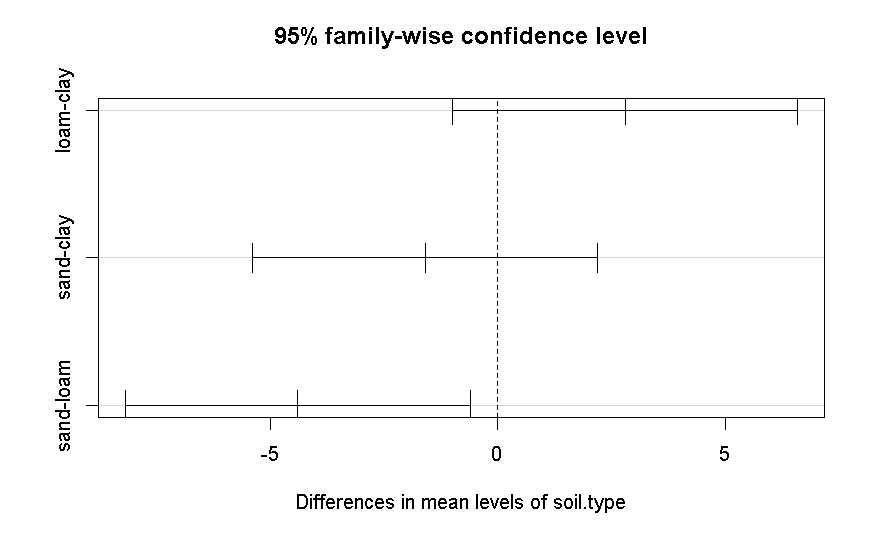

```r
plot(TukeyHSD(anova.yields))
```

```r
pairwise.t.test(dati.new$yields, dati.new$soil.type, p.adjust.method = "bonferroni")
```

```
    Pairwise comparisons using t tests with pooled SD

data:  dati.new$yields and dati.new$soil.type

     clay  loam
loam 0.234 -
sand 0.914 0.023

P value adjustment method: bonferroni
```

Riga 111)il valore soglia complessivo del modello è sempre 0.05, ma se voglio testare i confronti a coppie il valore soglia dovrebbe essere 0.05/numero categorie, perchè sto testando tutta una serie di sottoipotesi a partire dall’ipotesi principale…..dovremo essere più severi nel stabilire il valore soglia. Il metodo più severo e appropriato sarebbe quindi il test di bonferroni.Entrambi i modelli cmq “correggono già il p-value aggiustandolo”, in modo da poter leggere il valore soglia sempre come 0.05 come se fosse 0.16. Il metodo bonferroni è però quello più severo e migliore.